# Replication of Faber’s A Quantitative Approach to Tactical Asset Allocation - Managing Risk

#### Importing the data into R

Each asset’s class price series has been saved as a CSV. The packages used for performance analysis and backtesting require the data to be xts objects which are created by the following code.

```r
#remove past data
rm(list = ls(envir = globalenv()),envir = globalenv()) #clear Vars from global enviroment
#load required packages
library(PerformanceAnalytics)
library(quantstrat)
#declare symbols
symbols <- c("TBILLS","SP500","EAFE","US10YR","GSCI","NAREIT","CPI")
#use quantmod function to load data as xts objects
getSymbols(symbols,
  src = "csv",
  dir="../Data/CSV files",
  col.names=c("Close"))
```

```
[1] "TBILLS" "SP500"  "EAFE"   "US10YR" "GSCI"   "NAREIT" "CPI"
```

```r
#also load TBILL YIELDS
getSymbols("TBILLYIELDS",
  src = "csv",
  dir="../Data/CSV files",
  col.names=c("Close"))
```

```
[1] "TBILLYIELDS"
```

```r
#Define the asset to look at calcs for - ideally do this in a loop at the end
assetname <- "EAFE"
asset <- get(assetname)
#Define the subset period
SubsetPeriod <- "1973-01-31::2008-12-31"
```

#### Managing Risk

Faber introduces a timing system for investors to use to manage the risk. Lets chart the 10 month simple moving average

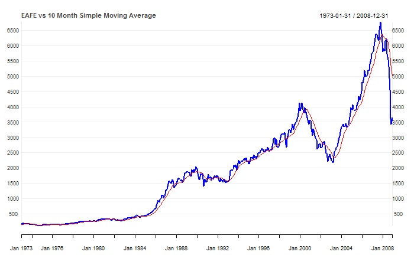

```r
myChart_Theme <- chart_theme() #Create a chart_theme
myChart_Theme$col$line.col <- "blue"
SMAperiod <- 10
chart_Series(Cl(asset),
  name = paste(assetname," vs 10 Month Simple Moving Average",sep = ""),
  theme=myChart_Theme,
  type = "line",
  subset = SubsetPeriod,
  TA = 'add_SMA(n=SMAperiod, on=1, col="red")'
  )
```

```r
# #why doesn't this for loop work????
# for(symbol in symbols[2:6]){
#   assetname <- symbol
#   asset <- get(assetname)
#
#   chart_Series(Cl(asset),
#     name = paste(assetname," vs 10 Month Simple Moving Average",sep = ""),
#     theme=myChart_Theme,
#     type = "line",
#     subset = SubsetPeriod,
#     TA = 'add_SMA(n=SMAperiod, on=1, col="red")'
#     )
# }
```

To - do

ylog = TRUE, ylim = c(40,6000), date.format = “%Y”, major.ticks = “years”,

- make it pull asset as variable, get log chart
- chart.posn (blotter) to show when in and out? *add drawdown
- look at adding visualisation when its in / out of the market http://timelyportfolio.blogspot.co.za/2011/08/drawdown-visualization.html
- add legend

#### Calculating returns

```r
library(dplyr)
AllAssets <- cbind.xts(Cl(asset),
                       Cl(TBILLYIELDS))
#create dataframe - tidyverse not compatible with xts?
AllAssets.df <- data.frame(date=index(AllAssets), coredata(AllAssets)) #, row.names = index(AllAssets))
#rename column for the Asset
colnames(AllAssets.df)[2] <- "Asset.Close"
#mutate new columns
AllAssets.df  <- mutate(AllAssets.df,
  "10mSMA" = rollmean(Asset.Close,10,fill = 0,align = "right"),
  "Asset.ret" = c(0,diff(Asset.Close)/lag(Asset.Close)[-1]),
  "Rf.ret" = lag((TBILLYIELDS.Close/100)/12),
  "signal" = lag(ifelse(Asset.Close>`10mSMA`,1,0)),
  "Timing.ret" = ifelse(signal == 1,Asset.ret,Rf.ret)
)
rownames(AllAssets.df) <- index(AllAssets)
#detach the packagae dplyr as it isn't compatible with other packages?
detach(package:dplyr)
```

#### Calculating Stats

First lets create an xts of Returns

```r
SubsetPeriod <- "1972-12-31::2008-12-31"
AllAssets <- as.xts(AllAssets.df[,-1])
Returns <- cbind.xts(AllAssets$Asset.ret, AllAssets$Timing.ret)[SubsetPeriod]
colnames(Returns) <- c(assetname,"Timing")
#for calculating the sharpe ratio later
Rf.ret <- Return.calculate(TBILLS)[-1,]
Rf.ret <- Rf.ret[SubsetPeriod]
#create Cum returns for the chart
CumReturns <- 100*cumprod(1+Returns[-1,])
colnames(CumReturns) <- c(assetname,"Timing")
```

#### Chart the returns

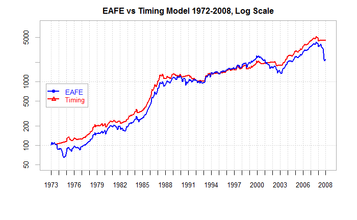

```r
chart.TimeSeries(CumReturns,
  main = paste(assetname," vs Timing Model ",substr(SubsetPeriod,1,4),"-",substr(SubsetPeriod,13,16),", Log Scale",sep = ""),
  date.format = "%Y",
  colorset = c(4,2),
  ylab = "",
  ylog = TRUE,
  ylim = c(50,7500),
  legend.loc = "left",
  major.ticks = "years",
  minor.ticks = FALSE)
```

todo * chart with periods highlighted (similar to position chart)

#### Drawdown chart

To give the reader a visual perspective of drawdowns we can chart

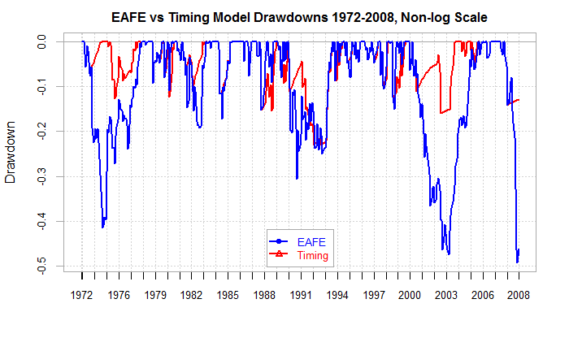

```r
chart.Drawdown(Returns,
  main = paste(assetname," vs Timing Model Drawdowns ",substr(SubsetPeriod,1,4),"-",substr(SubsetPeriod,13,16),", Non-log Scale",sep = ""),
  date.format = "%Y",
  colorset = c(4,2),
  ylab = "Drawdown",
  legend.loc = "bottom",
  major.ticks = "years",
  minor.ticks = FALSE)
```

to do - ensure same time period and x axis, print one above each other? area shading?

```r
stats <- rbind(Return.annualized(Returns,scale = 12)*100,
               StdDev.annualized(Returns,scale = 12)*100,
               SharpeRatio.annualized(Returns,Rf = Rf.ret$TBILLS.Close),
               maxDrawdown(Returns,scale = 12,invert = FALSE)*100,
               c(nrow(subset(Returns, Returns$asset >= 0))/nrow(Returns),nrow(subset(Returns, Returns$Timing.ret >= 0))/nrow(Returns))*100)
colnames(stats) <- c("SP500","TIMING")
rownames(stats) <- c("Return","Volatility","Sharpe","MaxDD","% Positive Months")
round(stats,2)
```

[output not shown]

To do: *fix positive months* SHARPE RF!!!! * feed in correct Rf for period to get sharpe correct * format percentages * add $100 becomes and inflation CAGR * loop for other asset classes * add for another asset class * confirm Rf / charpe sharpe to feed off Rf

#### Chart Rolling Performance

[figure not shown]

```r
charts.RollingPerformance(Returns,
                          main = "SP500 Total Returns vs Timing Total Returns (1973-2012)",
                          date.format = "%Y",
                          colorset = c(4,2),
                          ylog = FALSE,
                          minor.ticks =FALSE)
```

To do:

- calculate returns for year before so rolling returns correct from day 1
- Look at bad data in 1975-1984
- change scale to 6 months?

#### Position chart

now can create position chart